```r
library(tidyverse)
library(lubridate)
```

First we should read and save the tabels into different variables.

```r
calories <- read_csv("~/Desktop/google_case_study/Fitabase Data 4.12.16-5.12.16/dailyCalories_merged.csv")
intensities <- read_csv("~/Desktop/google_case_study/Fitabase Data 4.12.16-5.12.16/dailyIntensities_merged.csv")
steps <- read_csv("~/Desktop/google_case_study/Fitabase Data 4.12.16-5.12.16/dailySteps_merged.csv")
heartrate <- read_csv("~/Desktop/google_case_study/Fitabase Data 4.12.16-5.12.16/heartrate_seconds_merged.csv")
weight <- read_csv("~/Desktop/google_case_study/Fitabase Data 4.12.16-5.12.16/weightLogInfo_merged.csv")
sleep <- read_csv("~/Desktop/google_case_study/Fitabase Data 4.12.16-5.12.16/minuteSleep_merged.csv")
```

It looks like out date data is not formatted correctly so lets fix it and change the type to data frame and daily data to monthly data in calories table.

```r
calories <- as.data.frame(calories)
calories$ActivityDay <- mdy(calories$ActivityDay)
```

Now we can create a month data and create a sum of calories for this table.

```r
calories_total <- calories %>%
  mutate(month = format(ActivityDay, "%Y-%m")) %>%
  group_by(Id, month) %>%
  summarize(total_act = sum(Calories))
```

[output not shown]

Now we have the month, id and calorie data we can create a better table to better see the summed results of this table.

```r
head(calories_total)
```

```
## # A tibble: 6 × 3
## # Groups:   Id [3]
##           Id month   total_act
##        <dbl> <chr>       <dbl>
## 1 1503960366 2016-04     35799
## 2 1503960366 2016-05     20510
## 3 1624580081 2016-04     28401
## 4 1624580081 2016-05     17583
## 5 1644430081 2016-04     54252
## 6 1644430081 2016-05     30087
```

The calories total table is done, lets inspect other tables.

```r
str(heartrate)
```

```
## spc_tbl_ [2,483,658 × 3] (S3: spec_tbl_df/tbl_df/tbl/data.frame)
##  $ Id   : num [1:2483658] 2.02e+09 2.02e+09 2.02e+09 2.02e+09 2.02e+09 ...
##  $ Time : chr [1:2483658] "4/12/2016 7:21:00 AM" "4/12/2016 7:21:05 AM" "4/12/2016 7:21:10 AM" "4/12/2016 7:21:20 AM" ...
##  $ Value: num [1:2483658] 97 102 105 103 101 95 91 93 94 93 ...
##  - attr(*, "spec")=
##   .. cols(
##   ..   Id = col_double(),
##   ..   Time = col_character(),
##   ..   Value = col_double()
##   .. )
##  - attr(*, "problems")=<externalptr>
```

It looks like heartrate$Time is not formatted in a correct way, we should fix it. We can format this table so that we can get avarage of hearth rate for each month.

```r
heartrate <- as.data.frame(heartrate)
heartrate$Time <- mdy_hms(heartrate$Time)
heartrate_total <- heartrate %>%
  mutate(month = format(Time, "%Y-%m")) %>%
  group_by(Id, month) %>%
  summarize(heartrate_mean = mean(Value))
```

[output not shown]

It is done, we can see the table now.

```r
head(heartrate_total)
```

```
## # A tibble: 6 × 3
## # Groups:   Id [4]
##           Id month   heartrate_mean
##        <dbl> <chr>            <dbl>
## 1 2022484408 2016-04           79.9
## 2 2022484408 2016-05           80.7
## 3 2026352035 2016-04           91.1
## 4 2026352035 2016-05           94.8
## 5 2347167796 2016-04           76.7
## 6 4020332650 2016-04           88.3
```

We shoulp aply a similar data wrangling to other tabels as well.

Sleeping data:

```r
str(sleep)
```

```
## spc_tbl_ [188,521 × 4] (S3: spec_tbl_df/tbl_df/tbl/data.frame)
##  $ Id   : num [1:188521] 1.5e+09 1.5e+09 1.5e+09 1.5e+09 1.5e+09 ...
##  $ date : chr [1:188521] "4/12/2016 2:47:30 AM" "4/12/2016 2:48:30 AM" "4/12/2016 2:49:30 AM" "4/12/2016 2:50:30 AM" ...
##  $ value: num [1:188521] 3 2 1 1 1 1 1 2 2 2 ...
##  $ logId: num [1:188521] 1.14e+10 1.14e+10 1.14e+10 1.14e+10 1.14e+10 ...
##  - attr(*, "spec")=
##   .. cols(
##   ..   Id = col_double(),
##   ..   date = col_character(),
##   ..   value = col_double(),
##   ..   logId = col_double()
##   .. )
##  - attr(*, "problems")=<externalptr>
```

```r
sleep$date <- mdy_hms(sleep$date)
sleep_total <- sleep %>%
  mutate(month = format(date, "%Y-%m")) %>%
  group_by(Id, month) %>%
  summarise(avarage_sleep = sum(value))
```

[output not shown]

Steps table:

```r
str(steps)
```

```
## spc_tbl_ [940 × 3] (S3: spec_tbl_df/tbl_df/tbl/data.frame)
##  $ Id         : num [1:940] 1.5e+09 1.5e+09 1.5e+09 1.5e+09 1.5e+09 ...
##  $ ActivityDay: chr [1:940] "4/12/2016" "4/13/2016" "4/14/2016" "4/15/2016" ...
##  $ StepTotal  : num [1:940] 13162 10735 10460 9762 12669 ...
##  - attr(*, "spec")=
##   .. cols(
##   ..   Id = col_double(),
##   ..   ActivityDay = col_character(),
##   ..   StepTotal = col_double()
##   .. )
##  - attr(*, "problems")=<externalptr>
```

```r
steps <- as.data.frame(steps)
steps$ActivityDay <- mdy(steps$ActivityDay)

steps_total <- steps %>%
  mutate(month = format(ActivityDay, "%Y-%m")) %>%
  group_by(Id, month) %>%
  summarise(average_steps = mean(StepTotal))
```

[output not shown]

The intensity and weight tables might be useful later on when we need to conduct some tests for statistical significance. For now we can go over last versions of our tables. Lets merge them into one singe table first.

```r
merged_total <- calories_total %>%
  left_join(heartrate_total, by = c("Id", "month")) %>%
  left_join(sleep_total, by = c("Id", "month")) %>%
  left_join(steps_total, by = c("Id", "month"))
```

```r
omit_merged <- na.omit(merged_total)
colnames(omit_merged)[3] <- "total_cal"
```

Let’s see the visuals for this merged data if there are some relationships between the variables.

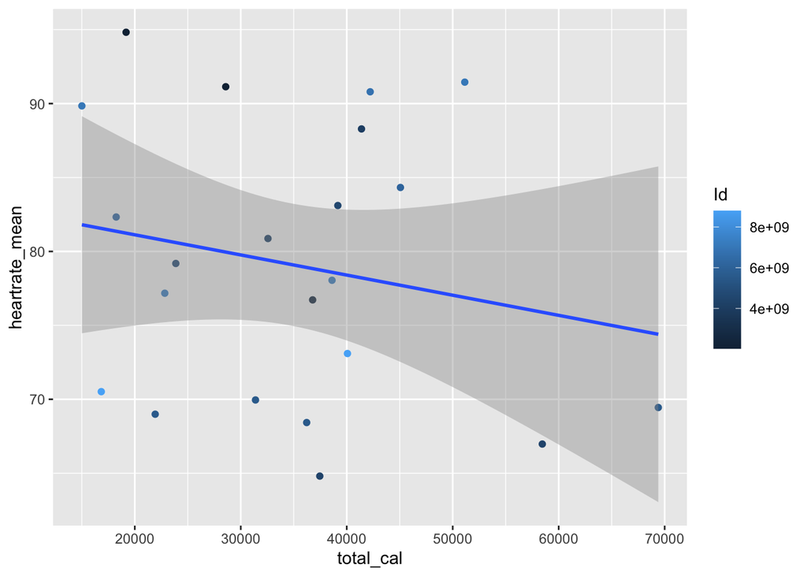

```r
heart_cal <- omit_merged %>%
  ggplot(mapping = aes(x = total_cal, y = heartrate_mean)) +
  geom_point(mapping = aes(color=Id)) +
  geom_smooth(method = "lm")

heart_cal
```

It is stange but it looks like there is a slightly week and negative relationship between total calories burned and heartrate.

Let’s see if there is such relationship between average steps and heartrate

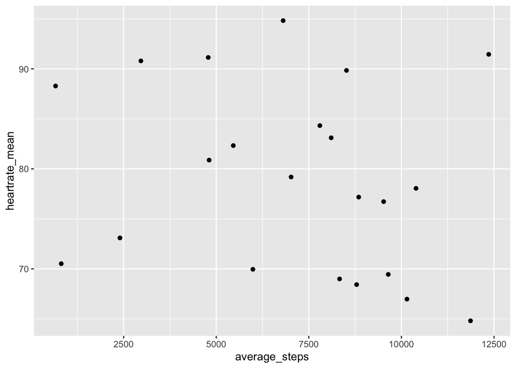

```r
step_heart <- omit_merged %>%
  ggplot(mapping = aes(x= average_steps, y=heartrate_mean)) +
  geom_point()

step_heart
```

It looks like we made a huge mistake here, because R thinks that the Id data is a continues data. Lets fix it.

```r
omit_merged$Id <- as.character(omit_merged$Id)
```

Now we can create those visuals again and see.

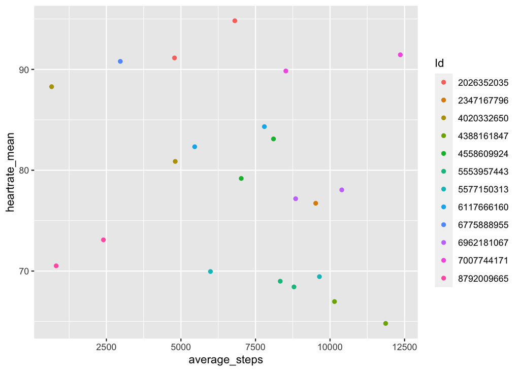

```r
omit_merged %>%
  ggplot(mapping = aes(x=average_steps ,y=heartrate_mean, color=Id)) +
  geom_point()
```